# Sprint 4 - Predicting Loan Interest Rate

## 🚨 This is the continuation of the previous notebook. If this is the first file you are opening during correctiong, considering reviewing the readme file to understand how this project is structured

In the previous files:

- ✅ we have looked at our dataset: we have cleaned it and we have split our data into datasets for each of the sprints and tasks
- ✅ we have created a model that can predict loan elegibility
- ✅ we have created a model that can predict loan grade
- ✅ we have created a model that can predict loan subgrade

In this file:

- we will create a model that can predict loan **interest rate**.

This notebook begins with the same boilerplate as the other ones (imports, basic feature toggles, etc...)

## Imports and initial setup

```python
import ipywidgets as widgets
from IPython.display import display, Markdown, Image, clear_output, HTML
import matplotlib.pyplot as plt
from matplotlib.patches import Rectangle
from itertools import groupby

import numpy as np
import pandas as pd
import seaborn as sns
from scipy import stats
from scipy.stats import chi2_contingency
import missingno as msno
import pygwalker as pyg
import pygwalker_utils.config as pyg_conf

import statsmodels.api as sm
import optuna

from random import random, seed
import sqlite3 as lite
import logging
import warnings
import ydata_profiling
import iplantuml
import xml.dom.minidom
from datetime import datetime, timedelta
import itertools
from os import path

from sklearn.feature_selection import SelectKBest, f_regression
from sklearn.metrics import (
    ConfusionMatrixDisplay,
    accuracy_score,
    recall_score,
    precision_score,
)
from sklearn.preprocessing import MinMaxScaler, StandardScaler, FunctionTransformer
from sklearn.impute import SimpleImputer
from sklearn.decomposition import PCA
from sklearn.linear_model import LinearRegression, LogisticRegression
from sklearn.model_selection import GridSearchCV
from sklearn.tree import plot_tree
from sklearn.metrics import (
    make_scorer,
    confusion_matrix,
    f1_score,
    PrecisionRecallDisplay,
)
from sklearn.pipeline import Pipeline
from sklearn.impute import KNNImputer
from sklearn.pipeline import make_pipeline
from sklearn.compose import ColumnTransformer
from sklearn.base import BaseEstimator, TransformerMixin
from sklearn.base import clone as clone_pipeline
from sklearn.metrics import classification_report, mean_squared_error

from sklearn.ensemble import RandomForestClassifier, ExtraTreesClassifier
from sklearn.linear_model import LogisticRegression
from xgboost import XGBClassifier
from sklearn.model_selection import GridSearchCV
from sklearn.svm import SVC
import shap
import yellowbrick
from yellowbrick.features import parallel_coordinates
from yellowbrick.regressor import ResidualsPlot

from imblearn.under_sampling import RandomUnderSampler
import joblib

import dask.dataframe as dd
from dask_ml.model_selection import train_test_split as dask_train_test_split

import os
from os import path

from utils import *
from utils import __

from autofeat import AutoFeatRegressor as AFR
from sklearn.model_selection import train_test_split as sklearn_train_test_split
from sklearn.exceptions import DataConversionWarning

import category_encoders as ce

seed(100)
pd.options.display.max_rows = 100
pd.options.display.max_colwidth = 50
util.check("done")
```

```
INFO: Running in offline mode. There might be newer releases available. Please check at https://github.com/Kanaries/pygwalker or https://pypi.org/project/pygwalker.
INFO: Pandas backend loaded 1.5.3
INFO: Numpy backend loaded 1.23.5
INFO: Pyspark backend NOT loaded
INFO: Python backend loaded
```

```
loading utils modules... ✅ completed
configuring autoreload... ✅ completed
✅
```

```python
%reload_ext loans_clean
%reload_ext loans_utils
import loans_clean
from loans_utils import *
```

```python
from imblearn.under_sampling import RandomUnderSampler
```

Let's use `black` to auto-format all our cells so they adhere to PEP8

```python
import lab_black

%reload_ext lab_black
util.patch_nb_black()
# fmt: off
# fmt: on
```

```python
from sklearn import set_config

set_config(transform_output="pandas")
```

```python
logger = util.configure_logging(jupyterlab_level=logging.WARN, file_level=logging.DEBUG)

warnings.filterwarnings("ignore", category=FutureWarning)

# import warnings
# warnings.filterwarnings('error', category=pd.errors.DtypeWarning)
```

```python
def ding(title="Ding!", message="Task completed"):
    """
    this method only works on linux
    """
    for i in range(2):
        !notify-send '{title}' '{message}'
```

## Feature Toggles

Let's also create a simple feature toggle that we can use to skip expensive operations during notebook work (to save myself some time!)

Set it to true if you want to run absolutely everything. Set to false to skip optional steps/exploratory work.

```python
def run_entire_notebook():
    run_all = False
    if not run_all:
        print("skipping optional operation")
    return run_all
```

```python
def perform_split_once_off():
    split_files = False
    if not split_files:
        print("skipping once-off splitting operation")
    return split_files
```

# Machine Learning

## Predicting Loan Interest Rate

For our next iteration, we want to predict loan **interest rate**.

Since the data cleaning and splitting are all done, this portion of the project will only require loading the right slice of data from disk!

```python
X_hyper = dataset_load(Sprint.interest, Phase.hyperparam, Dataset.X)
hyper_grade = dataset_load(Sprint.grade, Phase.hyperparam, Dataset.y)
hyper_subgrade = dataset_load(Sprint.subgrade, Phase.hyperparam, Dataset.y)
y_hyper = dataset_load(Sprint.interest, Phase.hyperparam, Dataset.y)

X_hyper = X_hyper.join(hyper_grade, how="left").join(hyper_subgrade, how="left")
```

```python
X_train = dataset_load(Sprint.interest, Phase.train, Dataset.X)
train_grade = dataset_load(Sprint.grade, Phase.train, Dataset.y)
train_subgrade = dataset_load(Sprint.subgrade, Phase.train, Dataset.y)
y_train = dataset_load(Sprint.interest, Phase.train, Dataset.y)

X_train = X_train.join(train_grade, how="left").join(train_subgrade, how="left")
```

## Checking class imbalance (grade)

Let's see how our interest rate changes based on the grade / subgrade:

```python
labels = pd.DataFrame(y_hyper).join(hyper_grade, how="left")
```

```
Loading from cache [./cached/charts/sprint4_interest_rate_distribution.png]
```

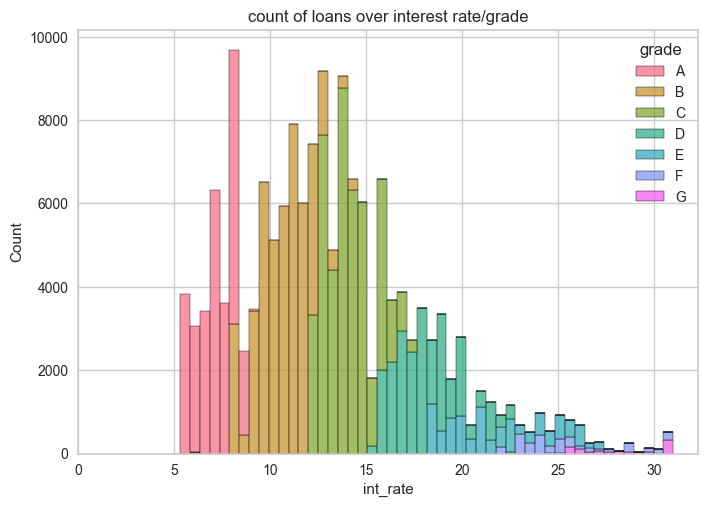

```python
@run
@cached_chart()
def sprint4_interest_rate_distribution():
    plot = sns.histplot(
        data=labels,
        x="int_rate",
        hue="grade",
        multiple="stack",
        bins=50,
        hue_order=["A", "B", "C", "D", "E", "F", "G"],
    )
    plt.xlim(0)
    plt.title("count of loans over interest rate/grade")
    return plot
```

It seems that using grade (which comes from the previous step), will help us enormously to predict interest rate.

## Checking class imbalance (subgrade)

```python
labels_subgrade = pd.DataFrame(y_hyper).join(hyper_subgrade, how="left")
```

```
Loading from cache [./cached/charts/sprint4_interest_rate_distribution_subgrade.png]
```

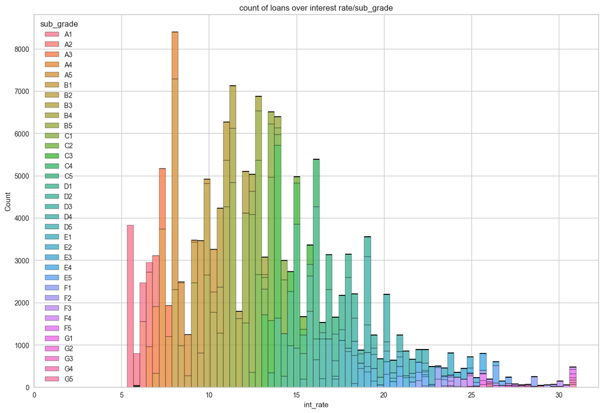

```python
@run
@cached_chart()
def sprint4_interest_rate_distribution_subgrade():
    plt.figure(figsize=(15, 10))
    plot = sns.histplot(
        data=labels_subgrade,
        x="int_rate",
        hue="sub_grade",
        multiple="stack",
        bins=70,
        hue_order=sorted(hyper_subgrade.value_counts().index),
    )
    plt.xlim(0)
    plt.title("count of loans over interest rate/sub_grade")
    return plot
```

We can see that subgrade provides even more granularity when it comes to predicting interest rate.

We might keep it in our models as well (although, we will have to encode them properly)

# Machine Learning - Predicting Loan Interest Rate

So, we have 2 options:

- Do the same thing we did for the last 2 parts: train multiple models (one per grade) and see how they perform.
  - Seeing how the data is distributed almost perfectly across the iridiscent colour spectrum, I expect pretty good predictive performance.
  - If we wanted to artificially inflate our performance, we could even create 1 model per subgrade, and it would get even less error.
- OR!... we could do something different and actually learn something extra:
  - Create 1 model only, and see how it performs across all of the grades/subgrades.
  - Try to understand how each of the features contribute to the predicted rate, etc...

So, we're going to be build a single model. Heteroscedasticity is majorly expected to make a guest appearance. Let's see if it shows up.

## Preparing the data

So, as we said before, now that we added grade and subgrade manually (after the cleaning and splitting pipelines in part 0 of the project), is, we need to do a tiny bit of additional encoding.

This encoding was not done in part 0 because I wanted to not include any of the other targets in each of the sprints datasets. In a real project, we would change the cleaning/splitting pipeline instead of doing this tiny manual change, but that takes a bit of rework, time, cognitive load, and the deadline is fast approaching. There is very little value in redoing this again from scratch now.

### one-hot encoding our grades and subgrades

One of the things we should do, is encode the new info we included.

```python
p_encode_grades = Pipeline(
    [
        (
            "onehot_grades",
            ce.OneHotEncoder(
                cols=["grade"],
                drop_invariant=True,
                return_df=True,
                use_cat_names=True,
                handle_unknown="ignore",
            ),
        ),
        (
            "onehot_subgrades",
            ce.OneHotEncoder(
                cols=["sub_grade"],
                drop_invariant=True,
                return_df=True,
                use_cat_names=True,
                handle_unknown="ignore",
            ),
        ),
        ("drop_1_grade", clean.ColumnDropper(["grade_G"])),
        ("drop_1_sub_grade", clean.ColumnDropper(["sub_grade_G4"])),
    ]
)

encoded_X_hyper = p_encode_grades.fit_transform(X_hyper)
```

```python
encoded_X_train = p_encode_grades.fit_transform(X_train)
```

## Predicting interest rate

In previous parts we have chosen, used and compared 4 classifiers (that worked with binary and multiclass labels):

- XGBClassifier
- Logisitc Regression
- Random Forest
- ExtraRandom Trees

This problem is a regression problem instead of a classification problem, so we will use and tune models that are the equivalent of those for. Just to see how they compare, and to give a sense of cohesion to the project.

I initially thought about not including Linear Regression as it seemed it will be too simple, but seeing how strongly grade/subgrade follow interest rate, I think even Linear Regression can get good results!

Let's see if my optimism is warranted!

So, we will be using and comparing these 4 regression models:

- `XGBRegressor()`
- `ElasticNet()`
  - We could use `LinearRegression()`, except that it's so simple it has no hyperparameters to tune. Instead of that, we will use a slightly more elaborate version of it called ElasticNet Regression, which has some hyper parameters to aid in l1 and l2 regularization.
- `RandomForestRegressor()`
- `ExtraTreesRegressor()`

```python
candidate_providers = {
    "xgbregressor": optuna_utils.XgbRegressorCandidateProvider(),
    "elasticnet": optuna_utils.ElasticNetRegressorCandidateProvider(),
    "extra_trees_regressor": optuna_utils.ExtRaTreesRegressorCandidateProvider(),
    "random_forest_regressor": optuna_utils.RandomForestRegressorCandidateProvider(),
}
```

```python
(
    X_train_split,
    X_test_split,
    y_train_split,
    y_test_split,
) = sklearn_train_test_split(encoded_X_train, y_train, test_size=0.2, random_state=42)
```

```python
def sprint4_tune_all_models():
    X = encoded_X_hyper
    y = y_hyper

    for model_name, candidate_provider in candidate_providers.items():
        print("training model:", model_name)
        study_name = f"sprint4_{model_name}"
        optuna_utils.create_optuna_study(
            study_name=study_name, allow_resume=True, direction="minimize"
        )
        objective = optuna_utils.build_objective_function(
            candidate_provider, X, y, scoring_function=mean_squared_error
        )
        optuna_utils.parallelize_optuna(
            study_name, n_processes=10, trials_per_process=2, objective=objective
        )


if run_entire_notebook():
    sprint4_tune_all_models()
```

```
skipping optional operation
```

```
Loading from cache [./cached/charts/sprint4_plot_performance.png]
```

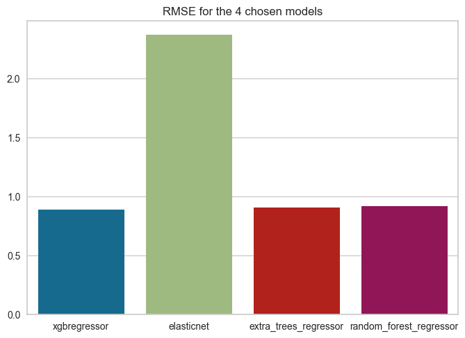

```python
@run
@cached_chart()
def sprint4_plot_performance():
    scores = {}
    for name in candidate_providers.keys():
        model = optuna_utils.get_study(f"sprint4_{name}")
        rmse = model.best_value ** (1 / 2)
        scores[name] = rmse

    scores = pd.Series(data=scores)
    plt.title("RMSE for the 4 chosen models")
    plt.ylabelel("error from interest rate")
    return sns.barplot(x=scores.index, y=scores)
```

It seems that, when trying to predict interest, all but the simplest model are able to get the prediction within $\pm 1$ percentage point to the target interest rate.

## Visualizing Residuals

```python
X, y = pandas_utils.xy_sample(X_train_split, y_train_split, n=5_000)
Xtest, ytest = pandas_utils.xy_sample(X_test_split, y_test_split, n=5_000)
```

```
Loading from cache [./cached/charts/sprint4_residuals_xgbregressor.png]
```

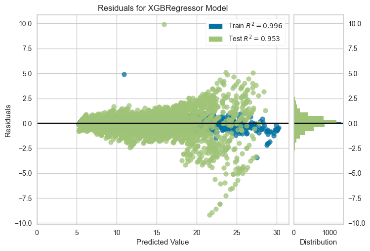

```python
@run
@cached_chart()
def sprint4_residuals_xgbregressor():
    ax = plt.gca()
    model = optuna_utils.get_best_model("sprint4_xgbregressor")
    visualizer = ResidualsPlot(model, is_fitted=False, ax=ax)

    visualizer.fit(X, y)
    visualizer.score(Xtest, ytest)
    ax.set_xlim(0)
    visualizer.show()
    return ax
```

1. Hello Heteroscedasticity, my dearest of friends! I missed you!
2. It is very interesting to see how the dots seem to follow an almost perfect straight line at 45' degrees... Let's see if the same happens with other models
   - we will overlay lines to try to highlight the patterns that we're seeing
3. Also worrying: this specific model seems to perform worse on unseen data, hinting to a small risk of overfitting. The other 3 models do not show such issue.

```
Loading from cache [./cached/charts/sprint4_residuals_elasticnet.png]
```

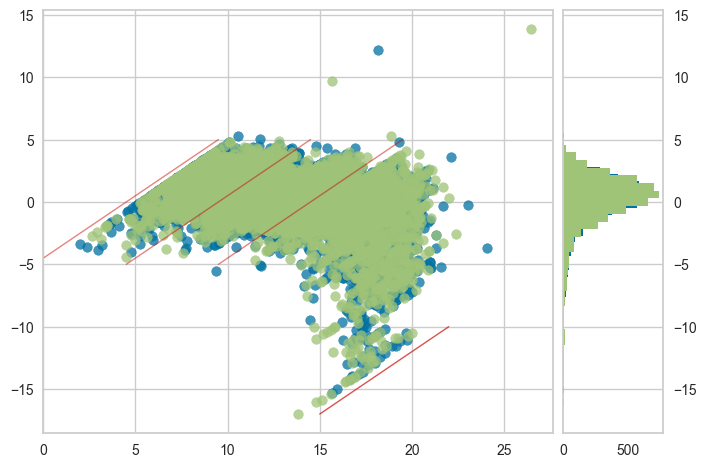

```python
@run
@cached_chart()
def sprint4_residuals_elasticnet():
    ax = plt.gca()
    model = optuna_utils.get_best_model("sprint4_elasticnet")
    visualizer = ResidualsPlot(model, is_fitted=False, ax=ax)

    visualizer.fit(X, y)
    visualizer.score(Xtest, ytest)
    # visualizer.show()
    ax.set_xlim(0)

    for i in range(0, 15, 5):
        ax.plot([i + 0 - 0.5, i + 10 - 0.5], [-5, 5], "r-", linewidth=1, alpha=0.5)

    ax.plot([15, 22], [-17, -10], "r-", linewidth=1, alpha=0.7)
    plt.show()
    return ax
```

```
Loading from cache [./cached/charts/sprint4_residuals_random_forests.png]
```

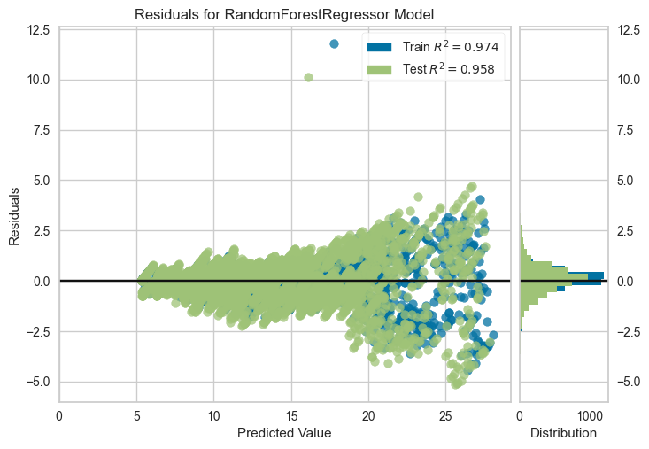

```python
@run
@cached_chart()
def sprint4_residuals_random_forests():
    ax = plt.gca()
    model = optuna_utils.get_best_model("sprint4_random_forest_regressor")
    visualizer = ResidualsPlot(model, is_fitted=False, ax=ax)

    visualizer.fit(X, y)
    visualizer.score(Xtest, ytest)
    ax.set_xlim(0)
    visualizer.show()
    return ax
```

```
Loading from cache [./cached/charts/sprint4_residuals_extra_trees.png]
```

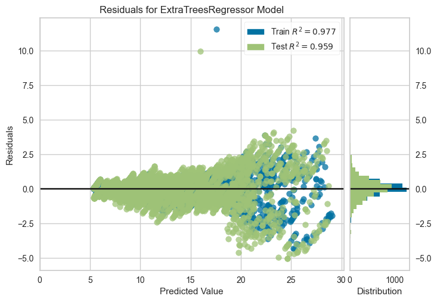

```python
@run
@cached_chart()
def sprint4_residuals_extra_trees():
    ax = plt.gca()
    model = optuna_utils.get_best_model("sprint4_extra_trees_regressor")
    visualizer = ResidualsPlot(model, is_fitted=False, ax=ax)

    visualizer.fit(X, y)
    visualizer.score(Xtest, ytest)
    ax.set_xlim(0)
    visualizer.show()
    return ax
```

It seems that heteroscedasticity appears in all models, as well as these linear patterns in the predictions.

Both of these artifacts are actually showing the same interesting trend:

- The higher the interest rate, the greater the residual
  - At the global level, heteroscedasticity
  - At a micro level, the linear trends show the same

## Understanding feature importance

```
Loading from cache [./cached/pickle/sprint4_get_feature_importances.pickle]
Loading from cache [./cached/charts/sprint4_plot_feat_importances.png]
```

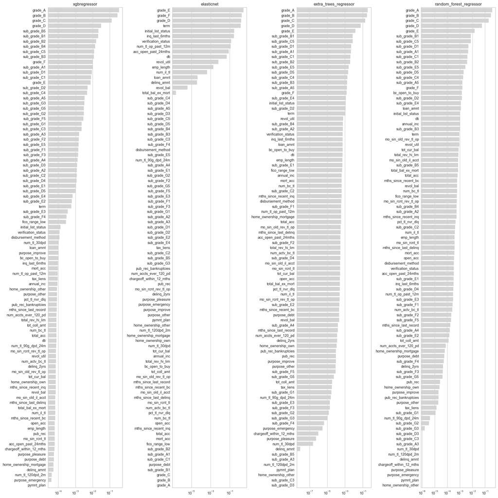

```python
@cached_with_pickle()
def sprint4_get_feature_importances():
    feat_importances = {}
    for name in candidate_providers.keys():
        model = optuna_utils.get_best_model(f"sprint4_{name}")
        X = encoded_X_hyper
        y = y_hyper
        model.fit(X, y)
        importances = models_utils.feat_importance_from(model, encoded_X_hyper.columns)
        feat_importances[name] = importances

    return feat_importances


feature_importances = sprint4_get_feature_importances()


@run
@cached_chart()
def sprint4_plot_feat_importances():
    fig, ax = plt.subplots(1, 4, figsize=(20, 20))
    for (names, importances), (row, col) in zip(
        feature_importances.items(), itertools.product(range(1), range(4))
    ):
        cax = ax[col]
        cax.set_title(names)
        feats = pd.Series(importances).sort_values(ascending=False)
        cax.set_xscale("log")
        sns.barplot(y=feats.index, x=feats, ax=cax, color="lightgrey")
    plt.tight_layout()
    return fig
```

A few insights:

- Just as expected, the top contributing features involve the grade columns (one-hot encoded).
- The best performing model uses almost ALL grade columns before getting into any of the other ones.
- The tiny differences between RandomForests and ExtRaForests seems to hint that they might have a similar workings underneath (they do!). But I am not sure this reasoning is valid/enough to make this statement for other models. Maybe it is just coincidence.

# Next steps

This is the end of sprint 4.

In this sprint, we have have built models to predict the loan interest rate using regression algorithms.

We have seen how all 3 tree-based models perform relatively well, except for XGBRegressor which shows small signs of overfitting.

The performance of these regression algorithms is quite remarcable (as expected), since two of the features they can use are grade and subgrade. It would have been really hard to understand if they performed poorly.

We are ready to jump into the next step: preparing the best model to deploy it to google cloud platform

Jump into the notebook for sprint5, the last notebook, whenever you are ready.